# NetworkPro.Sockets_BuildingchatApp

#### *Network Programming In Python Using Scokets:Building A Chat Application*

##### *Scokets Programming with Python*

##### **Run the server first and then client**

- **IP Address**
- **Ports & Sockets**
- **Creating A client**
- **Sending Messages**
- **Using Buffer**
- **Building The Messaging Functionality**
- **Sending Messages To Client**
- **Programming Send Funtionality**
- **Completing Our Chat App**

#### **IP Address**

Socket Programming With Python

Networking Basics

- [

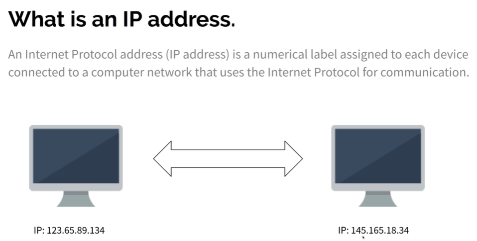

  ]
- **IP Address For a websites**
- [

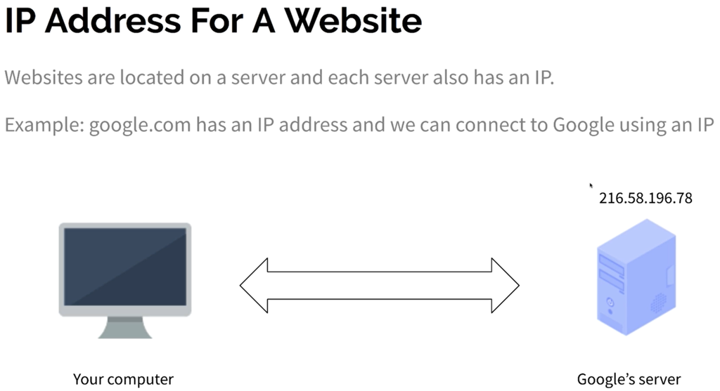

  ]
- [cmd commands]
- [**ipconfig /all**]
- [**nslookup myip.opendns.com resolver1.opendns.com**]
- [

[figure not shown]

  ]
- [**ping google.com**] of the server which connecting . this is the ip server which you connect to
- [

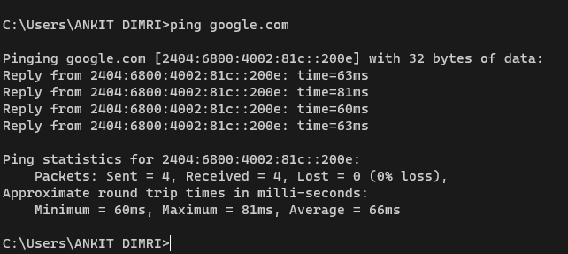

  ]
- [**ipconfig**]
- [**curl ifconfig.me**]
- [**curl myexternalip.com/raw**]
- [**curl ipecho.net/plain**]
- [**curl ifcfg.me**]
- [**DNS Domain name server**] domain to ip address - basically mapping domain name to ip address - [Domain Name Resolutions]

  ```
    Static vs Dynamic IP
        Dynamic IP : Which changes
        Static IP : Remains to the same
        ISP [Internet Service Provider] assign a dynamic IP to your device.
        Static IP's are mostly used by web servers. (e.g Google's Server)
  ```

- [

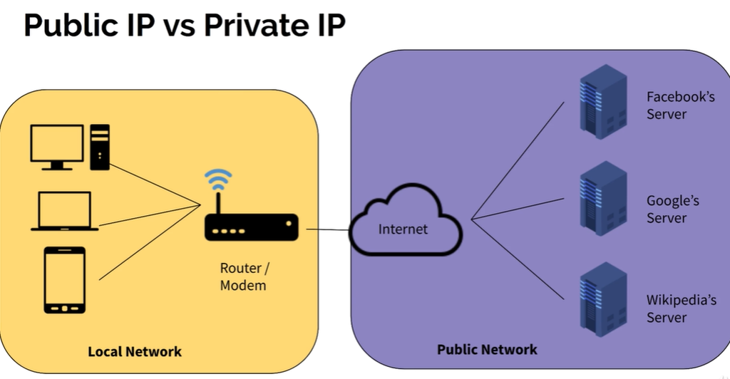

  ]
- [

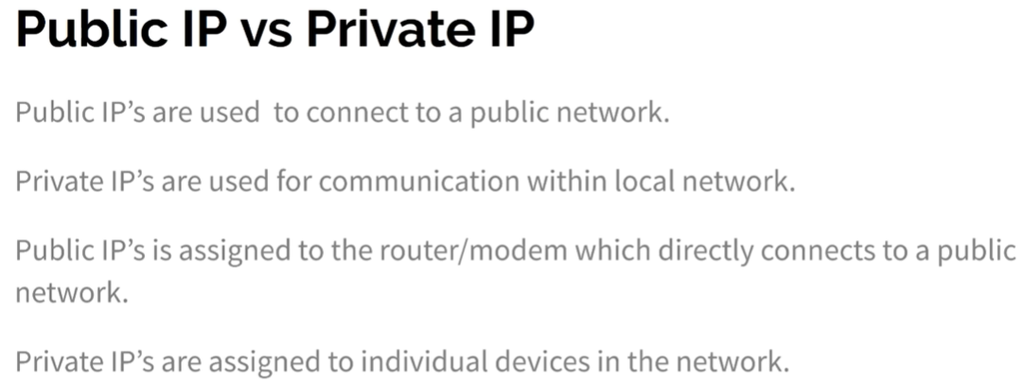

  ]

#### **Ports And Sockets**

- [

[figure not shown]

  ]
- [

[figure not shown]

  ]
- [

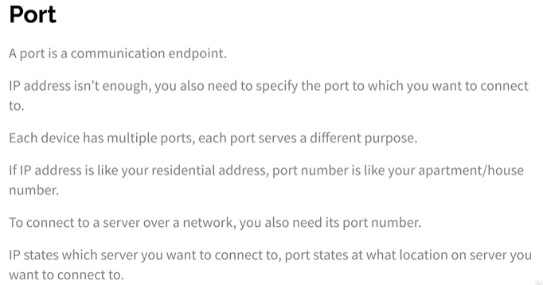

  ]
- [

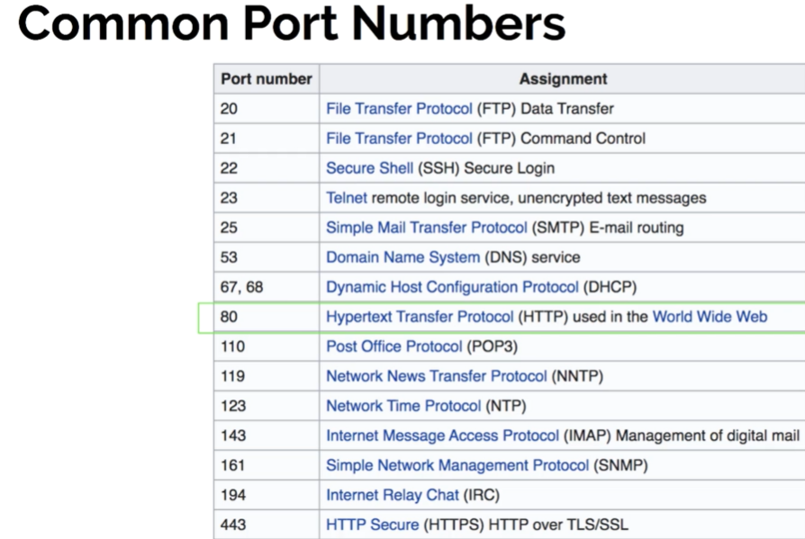

  ]
- [

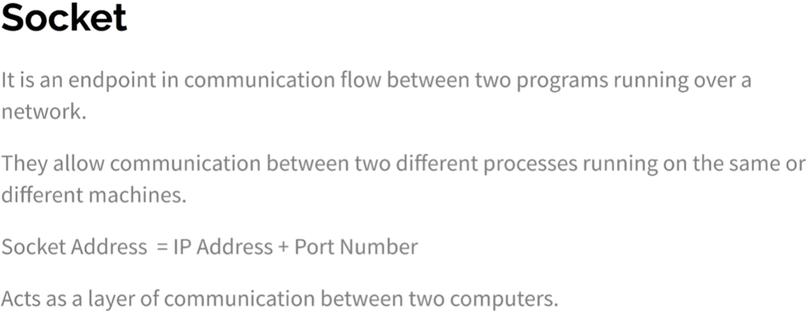

  ]
- [

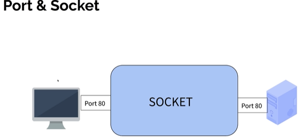

  ]
- [

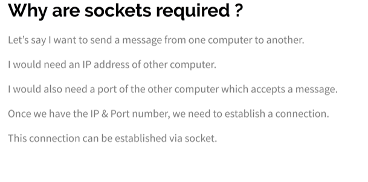

  ]
- [

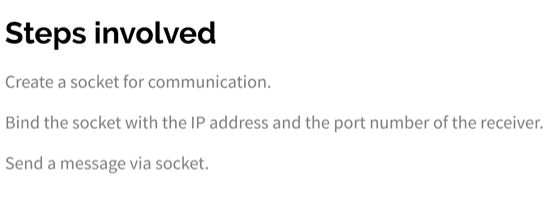

  ]
- [

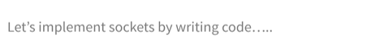

  ]

#### **Creating A client**

- [

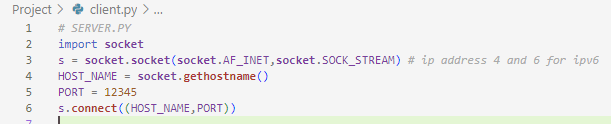

  ]
- [

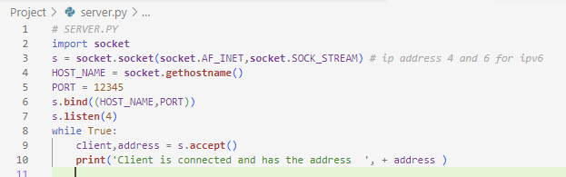

  ]

```python
import socket

s = socket.socket(socket.AF_INET,socket.SOCK_STREAM) # ip address 4 and 6 for ipv6
HOST_NAME = socket.gethostname()
print(HOST_NAME)
```

```
MSI
```

#### **SERVER.PY file name client.py**

```
import socket
s = socket.socket(socket.AF_INET,socket.SOCK_STREAM) # ip address 4 and 6 for ipv6
HOST_NAME = socket.gethostname()
PORT = 12345
s.connect((HOST_NAME,PORT))
```

```python
# SERVER.PY
import socket # sockets package
s = socket.socket(socket.AF_INET,socket.SOCK_STREAM) # ip address 4 and 6 for ipv6 [sock_stram - TCP which stance for [Transmission control protocal]]
HOST_NAME = socket.gethostname() #[name of your host ]
PORT = 12345
s.bind((HOST_NAME,PORT)) # sockets created here . we can't give directly . inside give the tuple,inside we give the host name and server
s.listen(4) # this number is for the backlog [listen for the connection to the client]
while True: #  while we created the infinite loop here
    client,address = s.accept() # once we stablished the connection . and we can save these two variables here
    print(address)
```

#### **Sending Messages**

- [

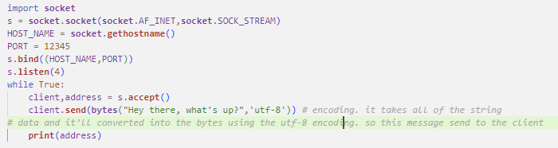

  ]
- [

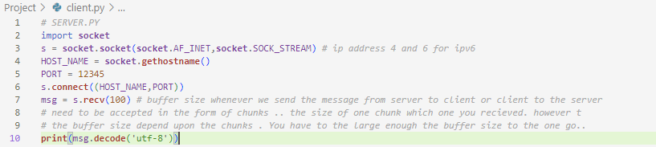

  ]

```python
import socket
s = socket.socket(socket.AF_INET,socket.SOCK_STREAM)
HOST_NAME = socket.gethostname()
PORT = 12345
s.bind((HOST_NAME,PORT))
s.listen(4)
while True:
    client,address = s.accept()
    client.send(bytes("Hey there, what's up?",'utf-8')) # encoding. it takes all of the string
# data and it'll converted into the bytes using the utf-8 encoding. so this message send to the client
    print(address)
```

```
('192.168.43.181', 53459)
```

#### **Using Buffer**

- [

[figure not shown]

  ]

**-A big size movie divide into the small chunks [client create short of buffer here which ensure that you get a smooth stream of movie as it is downloaded in chunks. so this is how the buffer is work over here] [The data get divided into the chunks as simple small chunks and each chunks downladed one at a time]**

```python
# SERVER.PY  client.py
import socket
s = socket.socket(socket.AF_INET,socket.SOCK_STREAM) # ip address 4 and 6 for ipv6
HOST_NAME = socket.gethostname()
PORT = 12345
s.connect((HOST_NAME,PORT))
msg = s.recv(10)
msg_1 = s.recv(12)
print(msg.decode('utf-8'))
print(msg_1.decode('utf-8'))
```

```python
import socket
s = socket.socket(socket.AF_INET,socket.SOCK_STREAM)
HOST_NAME = socket.gethostname()
PORT = 12345
s.bind((HOST_NAME,PORT))
s.listen(10)
while True:
    client,address = s.accept()
    client.send(bytes("Hey there, what's up?",'utf-8'))
    print(address)
```

```
('192.168.43.181', 53359)
```

**Remove the code to recieve and print message, we will add that later inside the loop**

```python
import socket
s = socket.socket(socket.AF_INET,socket.SOCK_STREAM)
HOST_NAME = socket.gethostname()
PORT = 12345
s.bind((HOST_NAME,PORT))
s.listen(10)
while True:
    client,address = s.accept()
    client.send(bytes("Hey there, what's up? I am leraning to code....Python Networking",'utf-8'))
    print(address)
    client.close()
```

```
('192.168.43.181', 54029)
```

- [

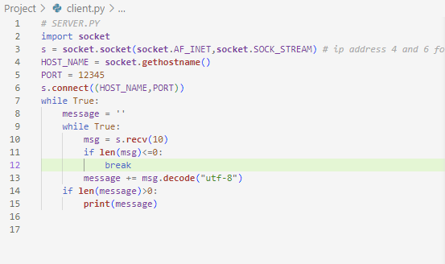

  ]
- So we sucessfully created a buffer and sucessfully set the size of buffer ...send the ,message in real time .

#### **Building The Messaging Functionality**

**and don't use the close connection**

#### **server and client conver**

**Server**

```python
import socket
s = socket.socket(socket.AF_INET,socket.SOCK_STREAM)
HOST_NAME = socket.gethostname()
PORT = 12345
s.bind((HOST_NAME,PORT))
s.listen(10)
client, address = s.accept()
while True:
    message = input('Server: ')
    client.send(bytes(message,'utf-8'))
    message_from_client = client.recv(50)
    print("Client"+message_from_client.decode('utf-8'))
    print(address)
```

```
ClientHey Andrew . How are you?
('192.168.43.181', 51138)
ClientI'm in village
('192.168.43.181', 51138)
ClientYEs
('192.168.43.181', 51138)
Clientokay
('192.168.43.181', 51138)
```

**client.py**

```python
import socket
s = socket.socket(socket.AF_INET,socket.SOCK_STREAM) # ip address 4 and 6 for ipv6
HOST_NAME = socket.gethostname()
PORT = 12345
s.connect((HOST_NAME,PORT))

while True:
    message = s.recv(50)
    print("Server:"+message.decode('utf-8'))

    message_to_send = input('Client:')
    s.send(bytes(message_to_send,"utf-8"))
```

#### **Sending Messages To Client**

**Layout.py** Tkinter

```python
from tkinter import * # The graphical user interface

root = Tk()

entry = Entry()
entry.pack(side=BOTTOM)

listbox = Listbox(root)
listbox.pack()

button = Button(root,text="Send")
button.pack(side=BOTTOM)

root.mainloop()
```

**server**

```python
import socket
from tkinter import * # The graphical user interface

def send(listbox,entry):
    message = entry.get()
    listbox.insert('end',message)
    entry.delete(0,END)

root = Tk()
root.title("Python Sendbox")
root.geometry("400x400")

entry = Entry()
entry.pack(side=BOTTOM, bg="gray", width=200, height=150,cursor="dot")

listbox = Listbox(root)
listbox.pack()

button = Button(root,text="Send", command=lambda:send(listbox,entry))
button.pack(side=BOTTOM)

root.mainloop()



s = socket.socket(socket.AF_INET,socket.SOCK_STREAM)
HOST_NAME = socket.gethostname()
PORT = 12345
s.bind((HOST_NAME,PORT))
s.listen(10)
client, address = s.accept()
while True:
    message = input('Server: ')
    client.send(bytes(message,'utf-8'))
    message_from_client = client.recv(50)
    print("Client"+message_from_client.decode('utf-8'))
    print(address)
```

#### **Programming Send Funtionality**

**server**

```python
import socket
from tkinter import * # The graphical user interface

def send(listbox,entry):
    message = entry.get()
    listbox.insert('end',"Server:"+message)
    entry.delete(0,END)
    client.send(bytes(message,'utf-8'))

def recieve(listbox):
    message_from_client = client.recv(50)
    # print("Client"+message_from_client.decode('utf-8'))
    listbox.insert('end',"Client: "+message_from_client.decode('utf-8'))


root = Tk()
root.title('Server')
root.geometry("400x400")

entry = Entry()
entry.pack(side=BOTTOM)
listbox = Listbox(root)
listbox.pack()

button = Button(root,text="Send", command=lambda:send(listbox,entry))
button.pack(side=BOTTOM)
rbutton = Button(root,text="Recieve", command=lambda:recieve(listbox))
rbutton.pack(side=BOTTOM)

s = socket.socket(socket.AF_INET,socket.SOCK_STREAM)
HOST_NAME = socket.gethostname()
PORT = 12345

s.bind((HOST_NAME,PORT))
s.listen(10)
client, address = s.accept()

root.mainloop()  # both the loops are nested loops
```

**client.py**

```python
import socket
from tkinter import *

def send(listbox,entry):
    message = entry.get()
    listbox.insert('end',"Client: "+message)
    entry.delete(0,END)
    s.send(bytes(message,"utf-8"))
    recieve(listbox)

def recieve(listbox):
    message = s.recv(50)
    listbox.insert('end',"Server : "+message.decode('utf-8'))

root = Tk()
root.geometry("300x300")

entry = Entry()
entry.pack(side=BOTTOM)

listbox = Listbox(root)
listbox.pack()

button = Button(root,text="Send", command=lambda:send(listbox,entry))
button.pack(side=BOTTOM)

rbutton = Button(root,text="Recieve", command=lambda:recieve(listbox))
rbutton.pack(side=BOTTOM)
root.title('Client')

s = socket.socket(socket.AF_INET,socket.SOCK_STREAM) # ip address 4 and 6 for ipv6
HOST_NAME = socket.gethostname()
PORT = 12345
s.connect((HOST_NAME,PORT))

root.mainloop()
```

#### **Completing Our Chat App**

**server**

```python
import socket
from tkinter import * # The graphical user interface

def send(listbox,entry):
    message = entry.get()
    listbox.insert('end',"Server:"+message)
    entry.delete(0,END)
    client.send(bytes(message,'utf-8'))

def recieve(listbox):
    message_from_client = client.recv(50)
    # print("Client"+message_from_client.decode('utf-8'))
    listbox.insert('end',"Client: "+message_from_client.decode('utf-8'))


root = Tk()
root.title('Server')
root.geometry("400x400")

entry = Entry()
entry.pack(side=BOTTOM)
listbox = Listbox(root)
listbox.pack()

button = Button(root,text="Send", command=lambda:send(listbox,entry))
button.pack(side=BOTTOM)
rbutton = Button(root,text="Recieve", command=lambda:recieve(listbox))
rbutton.pack(side=BOTTOM)

s = socket.socket(socket.AF_INET,socket.SOCK_STREAM)
HOST_NAME = socket.gethostname()
PORT = 12345

s.bind((HOST_NAME,PORT))
s.listen(10)
client, address = s.accept()

root.mainloop()  # both the loops are nested loops
```

**client.py**

```python
import socket
from tkinter import *

def send(listbox,entry):
    message = entry.get()
    listbox.insert('end',"Client: "+message)
    entry.delete(0,END)
    s.send(bytes(message,"utf-8"))
    recieve(listbox)

def recieve(listbox):
    message = s.recv(50)
    listbox.insert('end',"Server : "+message.decode('utf-8'))

root = Tk()
root.geometry("300x300")

entry = Entry()
entry.pack(side=BOTTOM)

listbox = Listbox(root)
listbox.pack()

button = Button(root,text="Send", command=lambda:send(listbox,entry))
button.pack(side=BOTTOM)

rbutton = Button(root,text="Recieve", command=lambda:recieve(listbox))
rbutton.pack(side=BOTTOM)
root.title('Client')

s = socket.socket(socket.AF_INET,socket.SOCK_STREAM) # ip address 4 and 6 for ipv6
HOST_NAME = socket.gethostname()
PORT = 12345
s.connect((HOST_NAME,PORT))

root.mainloop()
```

```
                                                                                                             Complete
```